# Intro to Extensive Form Games

with Connor T. Wiegand

### Games in Sequence

- So far, we’ve modeled games as occurring simultaneously
  - The representation of choice for these games is called “Normal Form” or “Srategic Form”
  - The primary tool is a payoff matrix
    - Other than some geometric bookkeeping, this tool is pretty straightforward to use
    - Provides direct access to our so-called “good predictions”
- However, we may think of games as occurring *in-sequence* where one player makes a move and the other(s) respond
  - The payoff matrix will not be as helpful here
  - Instead, we will use trees :evergreen_tree:
  - This representation (e.g., model) is known as “Extensive Form”

### Components of a game tree

- This is called the Entrant Game
- The *node* at the top represents the player who goes first in the game
  - This is called the *root node*
- *Edges* connect the nodes, and represent strategies
- Payoffs are shown at the bottom in the order of ($\pi_1, \pi_2$)
  - These are called *terminal nodes*
- Each non-terminal node is a player

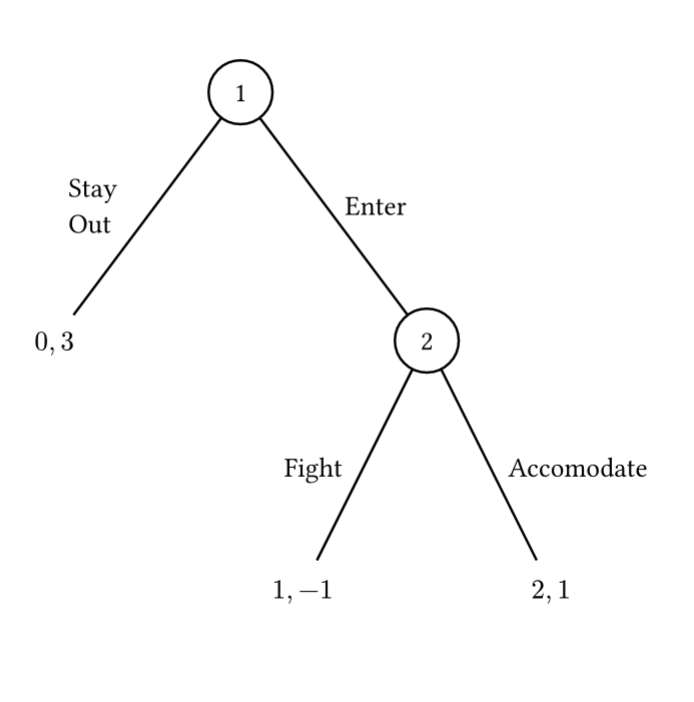

### Using Extensive Form Games

- Each “level” (often a horizontal row) of the game represents a *stage* of the game
  - In other economics classes, you might call this a *period*
- We can trace out a path on the game tree to represent an *outcome* of a game
- At times, it will also be helpful to circle the payoffs that result from this outcome (I’ve omitted that here though)

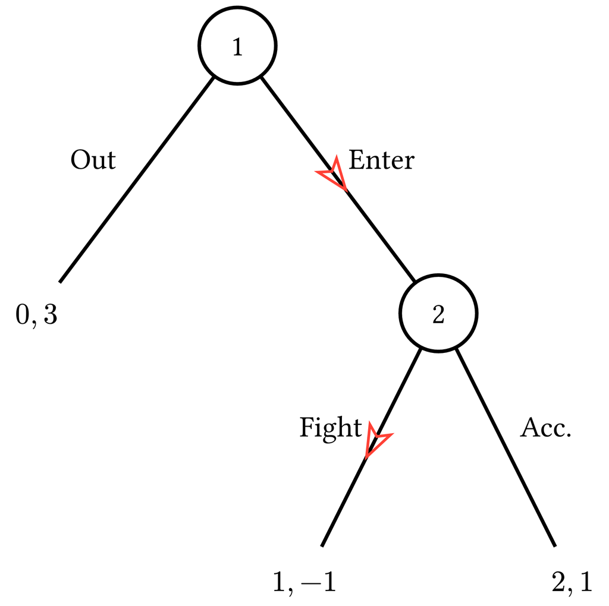

### A Refinement

- Previously, we used the term “strategy” interchangeably with “move” and “action”
- However, you might recall that this was the following definition:
  - > **Def:** A strategy is an information contingent plan of action
- Now, this has real meaning: at different stages of the game, players have different information
  - Note that they still have common knowledge of the rules of the game + rationality
- What does *information-contingent* mean?

### Strategies in Extensive Form Games

- Since a strategy is information-contingent, it must include an action for each possible state of the world that could be realized
  - You have outfits in mind that vary based on the weather
- In this game, player 2’s strategies must capture a ‘move’ for *each* possible state of the world that player 2 knows they could end up at
  - Therefore, one such strategy is $(X,Z)$
  - As player 2, this reads “play $X$ if $P_1$ plays $A$, and play $Z$ if player 1 plays $B$.
  - Player 2’s full set of strategies is $S_2=\{(X,Z), (X,W), (Y,Z), (Y, W)\}$
- Player 1, on the other hand, still only has two possible moves (based on their own information)
  - $S_{1}=\{A, B\}$

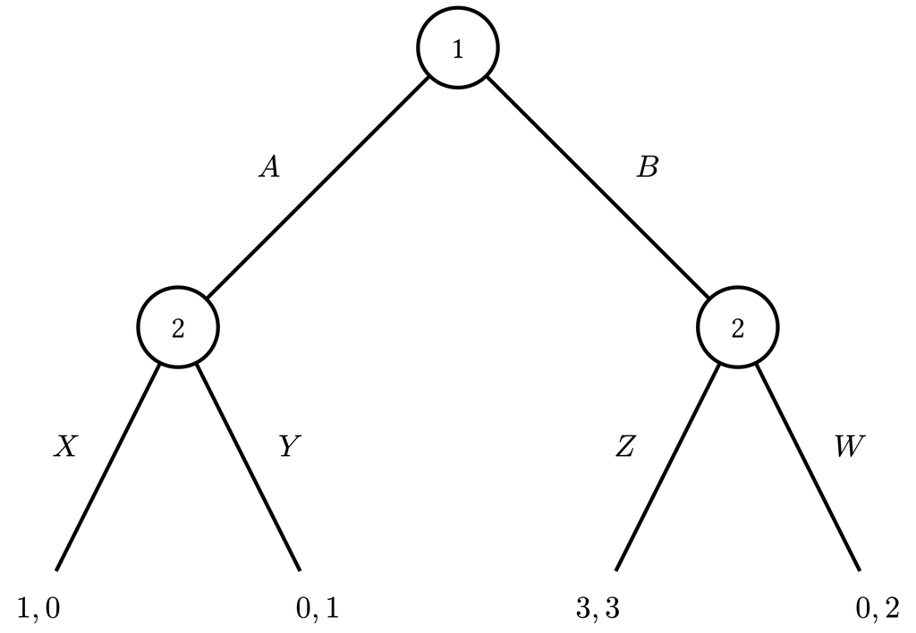

### How many strategies does each player have?

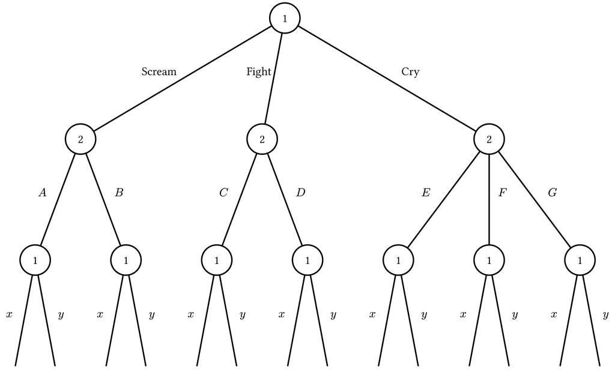

### How many strategies does each player have?

- That game was a little big…
- Examples of $P_2$’s strategies
  - $(B,C,F)$
  - $(A,D,G)$
  - $(A,C,E)$
  - There are $2\cdot 2\cdot 3=12$ in total
- Examples of $P_1$’s strategies
  - $\{\text{Fight}, (x,x,x,x,y,y,y)\}$
    - “Play Fight”, “play x I saw player 2 play any of A, B,C, D”, “play y if I saw player 2 play any of E, F, G”
  - Even though player 1 plays first, to analyze the game (e.g. to check deviations), a strategy for player 1 should include a plan of action at every info set!

### Drawing game paths

- We often don’t just want to specify an *outcome*
- We want to analyze a game so we can
  - Make a (hopefully good) prediction
  - Model the behavior of agents in a game
- To analyze a game, we want to describe the *strategies* that individuals are playing
- Therefore, we often trace out paths of *strategies* rather than *outcomes*
  - In this game, we end up at (the outcome associated with) $2,1$

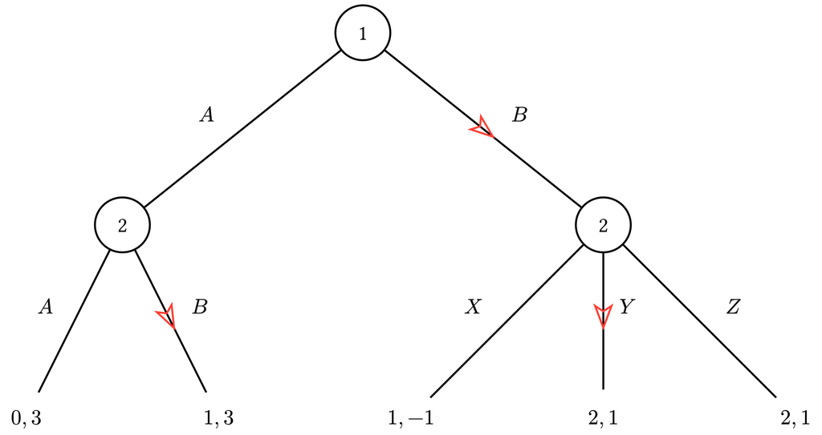

### Conversion from Extensive Form

- Consider the following game
  1. Write down each player
     - $P_1$, $P_2$
  2. Write down the strategy space for each player
     - $S_1=\{R,S\}$
     - $S_2 = \{(SG, SG), (SG, RD), (RD, SG), (RD, RD)\}$
  3. Write down the payoffs
     - okay, we get the idea

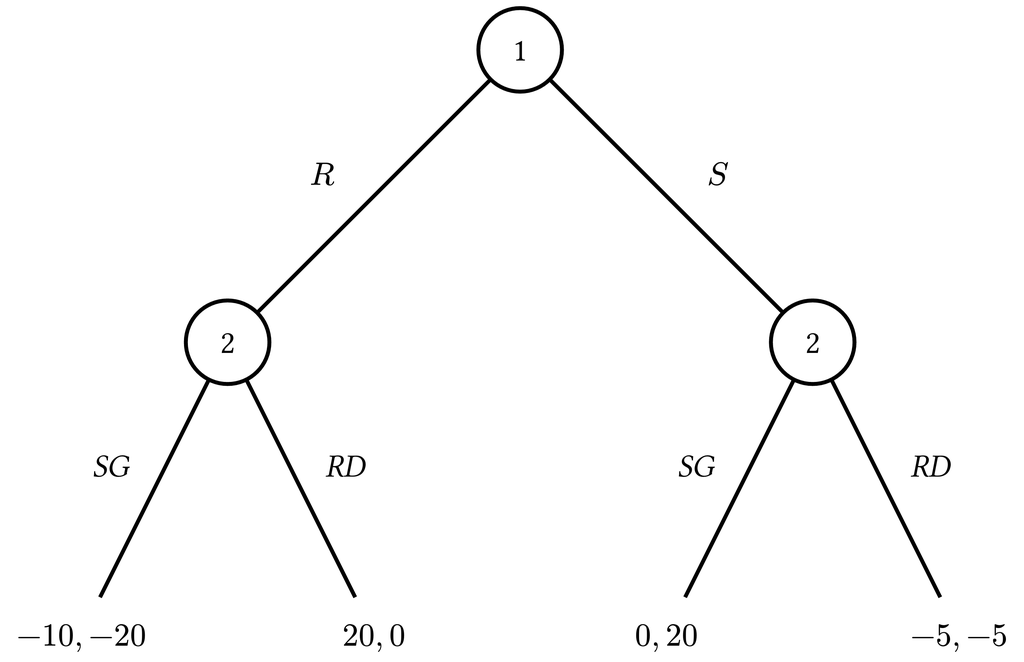

- What if that’s all the information you got?
  - E.g., these players, strategies, and payoffs

### You could make a table!

- We can convert extensive form games (*EFG*) into normal form games (*NFG*)
- How big is the payoff matrix you have from the previous slide?
  - 2x4

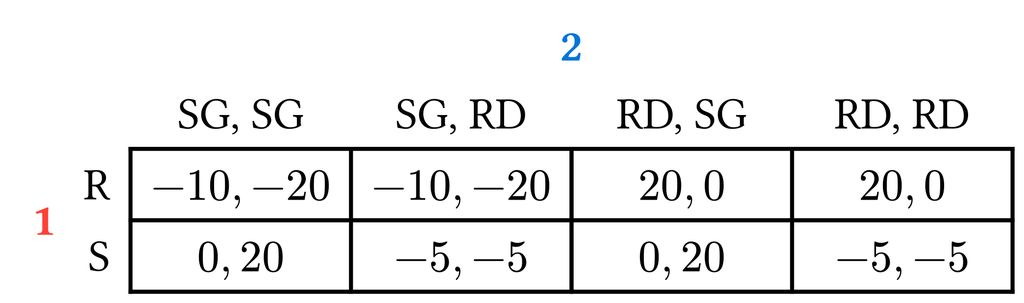

### Equilibria

- To find NE on a game tree, it turns out to be easiest to just convert the game into normal form and underline
  - In the game from the previous slide, we can see that the NE are (S, (SG, SG)), (R, (RD, SG)), and (R, (RD, RD))

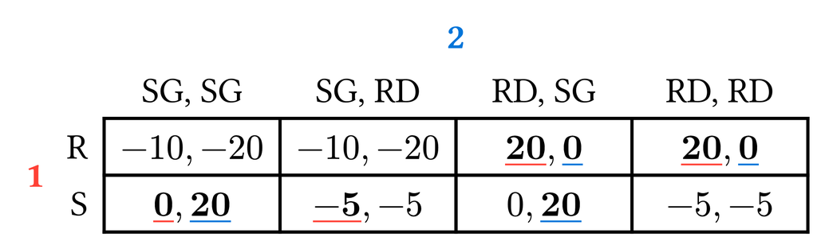

- Specifying payoffs like this in normal form might seem dumb silly, but it allows us to capture the more subtle notion of deviation from a strategy than normal form play does

### Gooder Predictions

- So, why use the tree?
- Consider the following example (again)

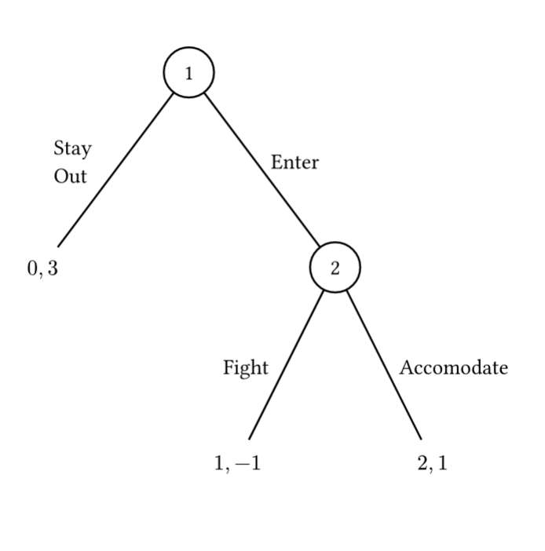

- Convert the game to normal form (and find the NE)

### Gooder Predictions (cont.)

- (Out, Fight) and (In, Accomodate) are NE

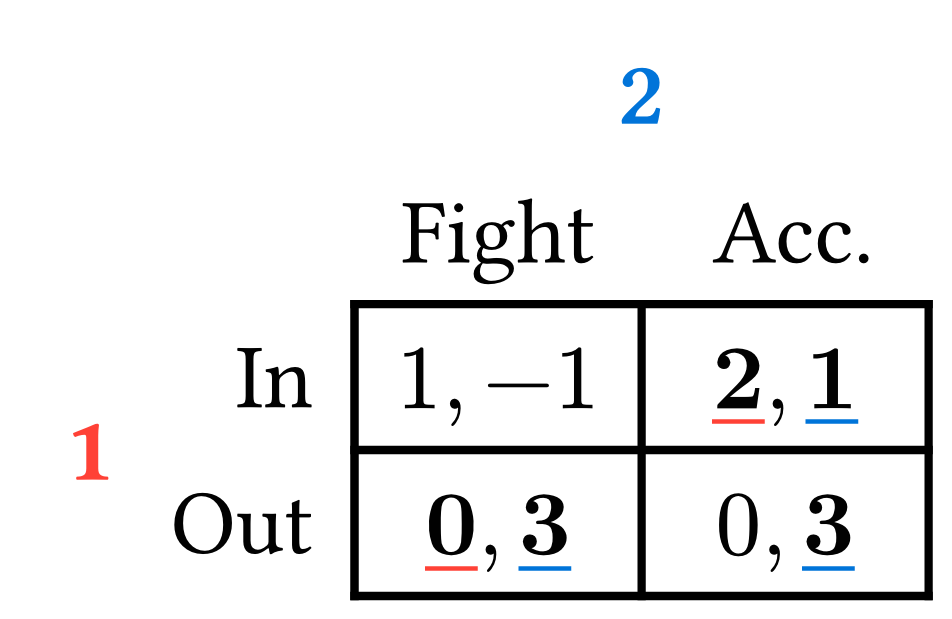

- Are both of these predictions equally as good?

### Gooder Games

- Game trees can help us find more refined versions of NE, which is indeed what we will be after
- However, there are a few more aspects of game trees to introduce
- It turns out that we can capture some pretty interesting games with this model

### Information

- We can easily visualize varying levels of *information* in a game using game trees
- So far, we have shown games where players knew what players before them did
- Each node is contained in whats called a *Singleton* information set
- However, game trees allow us to incorporate some leve of *hidden* information

### Information Sets

- In this game, the dashed line (often a bubble, both are equally common) represents where player 2 knows where they *could* be in a game

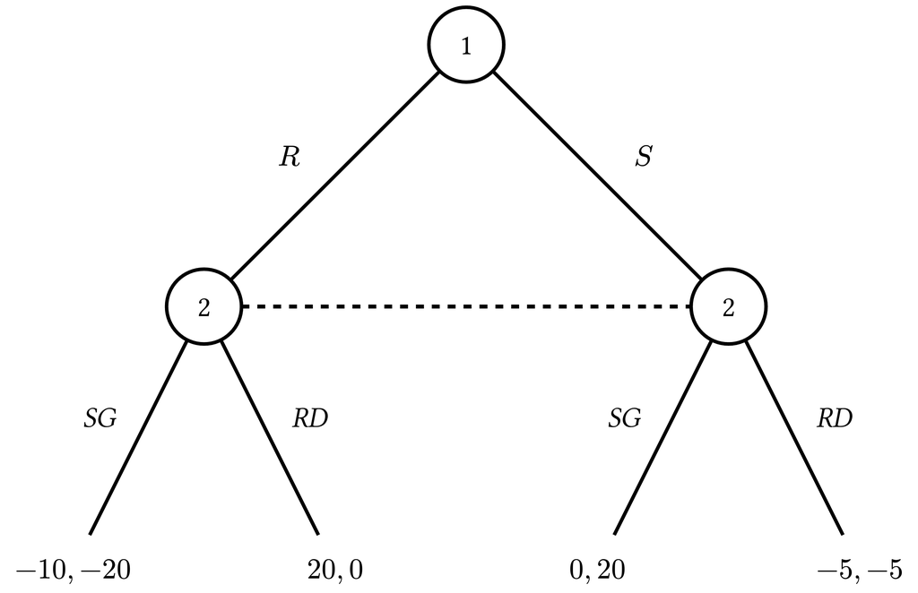

- This dashed line explicitly indicates the notion of *information sets*
  - Player 2 knows when they are **somewhere** on the dashed line
  - They just don’t know which spot they are at within the line
- Now what do strategies look like?

### Strategies and information

- Since player 2 now has less information, they will have a different kind of strategy
- In the previous example
  - Player 1’s strategies are still $\{R,S\}$
  - However, now player 2 can’t base their action on player 1’s move – *because they don’t see it*
  - Therefore, $S_2=\{SG, RD\}$
- In general, the strategy for a player in a game will have one action for each information set the player has in a game